# Twitter data

# Ⅰ. Why is covid-19 restrictions a urban problem:

The primary reason for implementing COVID-19 restrictions is to protect **public health** and reduce the number of infections and deaths from the virus. This is particularly important in mitigating the burden on **healthcare systems**, which can be overwhelmed by a large number of severe cases.The *COVID-19 pandemic* has had a significant economic impact, and restrictions can help to minimize this impact by reducing the spread of the virus and avoiding widespread outbreaks that could lead to further lock downs or business closures.

Governments also have obligations to other countries to prevent the spread of infectious diseases. By implementing COVID-19 restrictions, governments can help to protect the health of citizens in other countries and prevent the spread of the virus globally. It is important for governments to balance the need for restrictions with the need to minimize disruption to society and the economy. This can involve implementing a range of measures, such as vaccination campaigns, testing and contact tracing, and physical distancing and mask-wearing requirements, in addition to restrictions on gatherings and travel. Government policies can have a huge impact on people’s behavioral activities in the city and are a potential urban issue. And social media is a good reflection of people’s attitudes toward policies. Therefore, text analysis on twitter about **COVID** is very important.

On December 7, the China eases Covid restrictions on travel and production. This has generated a lot of discussion and attention on social media. We set the time point one week after the policy was introduced and followed people’s reactions to the policy and what was posted on twitter.

# Ⅱ. How you cleaned the tweets

## Data downloading

Using the rate_limit() command, we can check how many tweets/followers we can get for one search. For the current rate, we can get 900 tweets per 15 minutes in one search.

```r
options(scipen=999)

library(rtweet)

auth_setup_default()
```

```r
rate_limit()
```

```
## # A tibble: 263 × 5
##    resource                 limit remaining reset_at            reset
##    <chr>                    <int>     <int> <dttm>              <drtn>
##  1 /lists/list                 15        15 2022-12-18 22:22:29 15 mins
##  2 /lists/:id/tweets&GET      900       900 2022-12-18 22:22:29 15 mins
##  3 /lists/:id/followers&GET   180       180 2022-12-18 22:22:29 15 mins
##  4 /lists/memberships          75        75 2022-12-18 22:22:29 15 mins
##  5 /lists/:id&DELETE          300       300 2022-12-18 22:22:29 15 mins
##  6 /lists/subscriptions        15        15 2022-12-18 22:22:29 15 mins
##  7 /lists/members             900       900 2022-12-18 22:22:29 15 mins
##  8 /lists/:id&GET              75        75 2022-12-18 22:22:29 15 mins
##  9 /lists/subscribers/show     15        15 2022-12-18 22:22:29 15 mins
## 10 /lists/:id&PUT             300       300 2022-12-18 22:22:29 15 mins
## # … with 253 more rows
```

In our research, we use “COVID” as the search term, and searched for 10000 tweets, which is the maximum number we can get.When we presented the first 10 tweets we got, it can be verified that all these tweets are related to the Covid.

```r
COVID <- search_tweets("COVID", n = 10000, retryonratelimit = FALSE, include_rts = FALSE)
colnames(COVID)
```

```
##  [1] "created_at"                    "id"
##  [3] "id_str"                        "full_text"
##  [5] "truncated"                     "display_text_range"
##  [7] "entities"                      "metadata"
##  [9] "source"                        "in_reply_to_status_id"
## [11] "in_reply_to_status_id_str"     "in_reply_to_user_id"
## [13] "in_reply_to_user_id_str"       "in_reply_to_screen_name"
## [15] "geo"                           "coordinates"
## [17] "place"                         "contributors"
## [19] "is_quote_status"               "retweet_count"
## [21] "favorite_count"                "favorited"
## [23] "retweeted"                     "lang"
## [25] "possibly_sensitive"            "quoted_status_id"
## [27] "quoted_status_id_str"          "quoted_status"
## [29] "text"                          "favorited_by"
## [31] "scopes"                        "display_text_width"
## [33] "retweeted_status"              "quoted_status_permalink"
## [35] "quote_count"                   "timestamp_ms"
## [37] "reply_count"                   "filter_level"
## [39] "query"                         "withheld_scope"
## [41] "withheld_copyright"            "withheld_in_countries"
## [43] "possibly_sensitive_appealable"
```

```r
head(COVID$text, n=10)
```

```
##  [1] "BREAKING: The FDA has admitted that the COVID-19 experimental “vaccine” is linked to blood clotting.\n\nWe were right."
##  [2] "So the FDA finally came out and said that Pfizer’s Covid shot causes blood clots?\n\nOnly 2 years late!"
##  [3] "BREAKING REPORT: FDA now says Pfizer’s COVID-19 VACCINE Linked to Blood Clotting..."
##  [4] "@FreedmFightr1 I see a report today that old mate almost drowned in a river crossing border into qld during Covid lockdowns. They found a whole stash of weapons in his car and the qld police didn’t do anything. Has a very familiar ring to it once you are aware how a lot of tragedies are psy…
##  [5] "@KeepAlbertaRCMP OH NO YOU DON'T. During covid you took your orders from Trudeau and Ottawa. You should all be ashamed to sat back and allowed your blue brothers to be forced to get the job jab. I will NEVER forget that half the force sat back and DID NOTHING. Despicable!!"
##  [6] "500 mil dosis de vacuna contra el COVID-19, ingresarán a finales de enero en Honduras para menores de 6 meses a 5 años, informa el doctor Ernesto Dalas, en #𝑻𝒓𝒆𝒊𝒏𝒕𝒂𝑻𝒓𝒆𝒊𝒏𝒕𝒂 https://t.co/IIPWfJms6b"
##  [7] "@lizzyinyyc COVID negative, too, so feeling good about it"
##  [8] "Covid-19 variant BA.2.75 dominates cases as holidaymakers warned to take precautions https://t.co/FPyZKziLzY"
##  [9] "@KelliDPowers @covid_parent Fucking ignorant"
## [10] "Que onda q todos tienen covid, eso por infieles seguro"
```

## Text Mining: Data Cleaning

In this section, we cleaned up the tweets we acquired by removing the redundant characters. In the second part of our report, we have mentioned in detail which characters will be cleaned.

```r
#install.packages(c("tm","RTextTools","SnowballC"))

library(tm)
library(RTextTools)
library(SnowballC)
```

```r
COVID_Text <- data.frame(text = COVID$text)

myCorpus <- Corpus(VectorSource(COVID_Text$text))
myCorpus
```

```
## <<SimpleCorpus>>
## Metadata:  corpus specific: 1, document level (indexed): 0
## Content:  documents: 9999
```

```r
#     Defining the toSpace function
toSpace <- content_transformer(function(x, pattern) gsub(pattern, " ", x))

#     Removing special characters
myCorpus <- tm_map(myCorpus, toSpace, "@")
myCorpus <- tm_map(myCorpus, toSpace, "/")
myCorpus <- tm_map(myCorpus, toSpace, "]")
myCorpus <- tm_map(myCorpus, toSpace, "$")

#    Remove non-ASCII characters
myCorpus <- tm_map(myCorpus, function(x) iconv(x, "latin1", "ASCII", sub=""))

#    Remove numbers
myCorpus <- tm_map(myCorpus, removeNumbers)

#    Remove punctuation
myCorpus <- tm_map(myCorpus, removePunctuation)

#    Remove stopwords
myCorpus <- tm_map(myCorpus, removeWords, stopwords("english"))

#    Remove additional stop words
myCorpus <- tm_map(myCorpus, removeWords,c("By", "the", "http", "may", "ttp",
                                           "qhb...", "https", "http...", "for",
                                           "tco",
                                           "covid", "Covid", "COVID","The", "like", "just",
                                           "dont", "got", "will", "can", "long", "one",
                                           "know", "that", "didnt", "also", "take", "also",
                                           "even", "and", "its", "still", "and"))

#    Remove white space
myCorpus <- tm_map(myCorpus, stripWhitespace)

#    Remove common word suffixes and endings
myCorpus <- tm_map(myCorpus, stemDocument)

strwrap(myCorpus[[1]])
```

```
## [1] "BREAKING FDA admit experiment vaccin link blood clot We right"
```

# ⅠⅠⅠ. Text Mining: Creating a Document Term Matrix and Word Cloud

Here, we created a word cloud which is used to visually summarize the key themes of the tweets we acquired. The word cloud is created by displaying the most frequent used words in a document as larger, more prominent text, and the less important used words as smaller text.

```r
dtm <- DocumentTermMatrix(myCorpus)
dtm
```

```
## <<DocumentTermMatrix (documents: 9999, terms: 35519)>>
## Non-/sparse entries: 151293/355003188
## Sparsity           : 100%
## Maximal term length: 111
## Weighting          : term frequency (tf)
```

```r
dim(dtm)
```

```
## [1]  9999 35519
```

First, we can see the number of times some high frequency words appeared in the 10,000 tweets we obtained from the list below. The words are listed in descending order of frequency of occurrence.

```r
freq <- sort(colSums(as.matrix(dtm)), decreasing=TRUE)
head(freq, n=50)
```

```
## vaccin  peopl    que    get   mask   year    die   time    amp  death   test
##   1686   1082   1025    995    666    596    595    549    540    522    518
##    now   work    flu  never    you   that    les  think    day    its  virus
##    516    477    431    385    377    361    361    358    339    327    312
##    and   need    say   shot    pas   sick    por   mani  china   make    des
##    304    301    294    293    291    290    286    284    280    276    267
##   your   want   case   caus hospit  thing infect    del    los    but   live
##    264    262    257    256    253    251    249    249    248    248    248
##    see   back    new   last    con   what
##    247    247    246    244    244    243
```

The following graph shows directly the frequency of occurrence of the words related to Covid. It can be seen that the word “Vaccin”, which indicates “vaccine”, appears most frequently, it may be due to the ongoing discussion about whether people should get covid vaccine and whether there are side effects associated with the vaccine.The words “que”, “peopl” and “get” come next, these words may also have some relevance to vaccines, for example, “people queue to get a vaccine”. There are other words that show some other topics related to covid that have been discussed, for instance, “flu”, “die”, “mask”, etc. These words represent some of the popular topics in the daily news about covid.

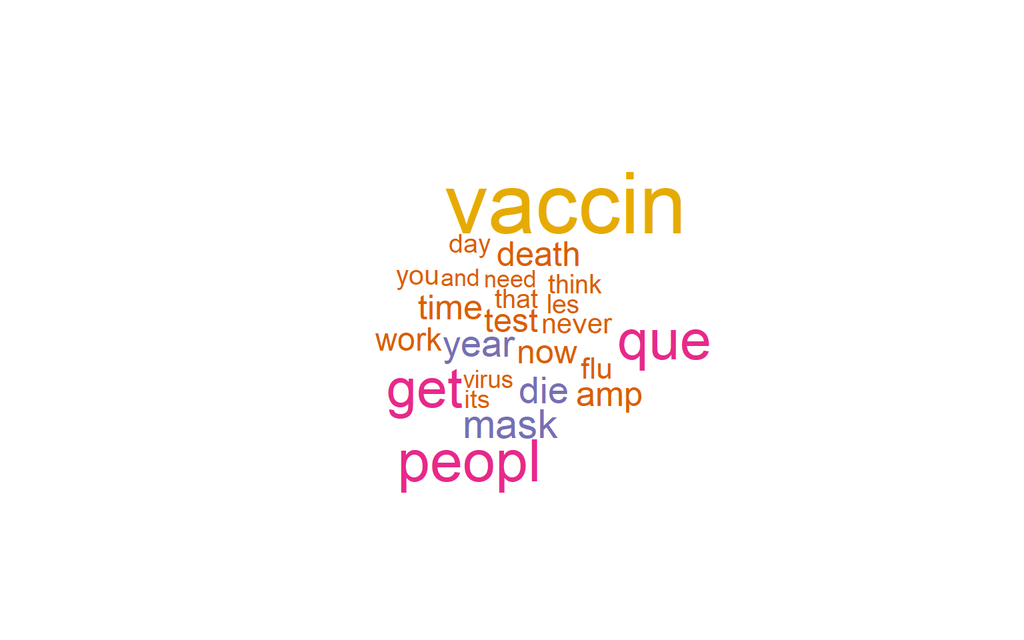

```r
#install.packages("wordcloud")
library(wordcloud)

wordcloud(names(freq), freq, min.freq=300, colors=brewer.pal(6, "Dark2"))
```